# Import Libraries

```python
import pandas as pd
import numpy as np
import matplotlib.pyplot as plt

from sklearn.model_selection import train_test_split
from sklearn.linear_model import LinearRegression
from sklearn.ensemble import RandomForestRegressor
from sklearn.metrics import mean_squared_error, mean_absolute_error, r2_score
```

## This chunk loads the Python libraries needed for data handling, visualization, model building, and model evaluation.

# Load the Abalone Training Dataset

```python
import os

os.chdir(r"C:\Users\Owner\Downloads\Abalone")

print(os.getcwd())
```

```
C:\Users\Owner\Downloads\Abalone
```

```python
import pandas as pd

abalone = pd.read_csv("train.csv/train.csv")
abalone.head()
```

|  | id | Sex | Length | Diameter | Height | Whole weight | Whole weight.1 | Whole weight.2 | Shell weight | Rings |
| --- | --- | --- | --- | --- | --- | --- | --- | --- | --- | --- |
| 0 | 0 | F | 0.550 | 0.430 | 0.150 | 0.7715 | 0.3285 | 0.1465 | 0.2400 | 11 |
| 1 | 1 | F | 0.630 | 0.490 | 0.145 | 1.1300 | 0.4580 | 0.2765 | 0.3200 | 11 |
| 2 | 2 | I | 0.160 | 0.110 | 0.025 | 0.0210 | 0.0055 | 0.0030 | 0.0050 | 6 |
| 3 | 3 | M | 0.595 | 0.475 | 0.150 | 0.9145 | 0.3755 | 0.2055 | 0.2500 | 10 |
| 4 | 4 | I | 0.555 | 0.425 | 0.130 | 0.7820 | 0.3695 | 0.1600 | 0.1975 | 9 |

## This reads the Kaggle Abalone training dataset into Python. The head() function displays the first five rows so you can inspect the structure of the data.

Examine Dataset Structure

```python
abalone.info()
abalone.describe()
```

```
<class 'pandas.core.frame.DataFrame'>
RangeIndex: 90615 entries, 0 to 90614
Data columns (total 10 columns):
 #   Column          Non-Null Count  Dtype
---  ------          --------------  -----
 0   id              90615 non-null  int64
 1   Sex             90615 non-null  object
 2   Length          90615 non-null  float64
 3   Diameter        90615 non-null  float64
 4   Height          90615 non-null  float64
 5   Whole weight    90615 non-null  float64
 6   Whole weight.1  90615 non-null  float64
 7   Whole weight.2  90615 non-null  float64
 8   Shell weight    90615 non-null  float64
 9   Rings           90615 non-null  int64
dtypes: float64(7), int64(2), object(1)
memory usage: 6.9+ MB
```

|  | id | Length | Diameter | Height | Whole weight | Whole weight.1 | Whole weight.2 | Shell weight | Rings |
| --- | --- | --- | --- | --- | --- | --- | --- | --- | --- |
| count | 90615.000000 | 90615.000000 | 90615.000000 | 90615.000000 | 90615.000000 | 90615.000000 | 90615.000000 | 90615.000000 | 90615.000000 |
| mean | 45307.000000 | 0.517098 | 0.401679 | 0.135464 | 0.789035 | 0.340778 | 0.169422 | 0.225898 | 9.696794 |
| std | 26158.441658 | 0.118217 | 0.098026 | 0.038008 | 0.457671 | 0.204428 | 0.100909 | 0.130203 | 3.176221 |
| min | 0.000000 | 0.075000 | 0.055000 | 0.000000 | 0.002000 | 0.001000 | 0.000500 | 0.001500 | 1.000000 |
| 25% | 22653.500000 | 0.445000 | 0.345000 | 0.110000 | 0.419000 | 0.177500 | 0.086500 | 0.120000 | 8.000000 |
| 50% | 45307.000000 | 0.545000 | 0.425000 | 0.140000 | 0.799500 | 0.330000 | 0.166000 | 0.225000 | 9.000000 |
| 75% | 67960.500000 | 0.600000 | 0.470000 | 0.160000 | 1.067500 | 0.463000 | 0.232500 | 0.305000 | 11.000000 |
| max | 90614.000000 | 0.815000 | 0.650000 | 1.130000 | 2.825500 | 1.488000 | 0.760000 | 1.005000 | 29.000000 |

## info() shows the number of rows, columns, data types, and missing values.

describe() gives summary statistics such as mean, standard deviation, minimum, and maximum values for numeric variables.

# Check for Missing Values

```python
abalone.isnull().sum()
```

```
id                0
Sex               0
Length            0
Diameter          0
Height            0
Whole weight      0
Whole weight.1    0
Whole weight.2    0
Shell weight      0
Rings             0
dtype: int64
```

## This checks whether any columns contain missing values. Missing values should be handled before fitting regression models.

# Separate Predictors and Target Variable

```python
X = abalone.drop(columns=["Rings"])
y = abalone["Rings"]
```

Rings is the target variable because it is used to estimate the age of the abalone. All other variables are used as predictors.

# Convert Categorical Variable into Dummy Variables

```python
X = pd.get_dummies(X, drop_first=True)
```

## The variable Sex is categorical, so it must be converted into numeric dummy variables before it can be used in regression models.

drop_first=True removes one category to avoid redundancy.

# Split the Dataset into Training and Validation Sets

```python
X_train, X_valid, y_train, y_valid = train_test_split(
    X, y, test_size=0.2, random_state=42
)
```

## This separates the data into training and validation sets.

The model learns from 80% of the data and is tested on the remaining 20%.

# Build Model 1 — Linear Regression

```python
lr = LinearRegression()

lr.fit(X_train, y_train)

lr_pred = lr.predict(X_valid)
```

## This builds a Linear Regression model.

The model learns the relationship between the predictors and Rings, then makes predictions on the validation data.

# Evaluate the Linear Regression Model

```python
print("Linear Regression Results")
print("RMSE:", np.sqrt(mean_squared_error(y_valid, lr_pred)))
print("MAE:", mean_absolute_error(y_valid, lr_pred))
print("R2:", r2_score(y_valid, lr_pred))
```

```
Linear Regression Results
RMSE: 2.023729374713583
MAE: 1.3931114577650345
R2: 0.6013104882981912
```

## This evaluates the Linear Regression model using:

RMSE: average prediction error with larger errors penalized more. MAE: average absolute prediction error. R²: percentage of variation in Rings explained by the model.

# Build Model 2 — Random Forest Regression

```python
rf = RandomForestRegressor(
    n_estimators=300,
    random_state=42
)

rf.fit(X_train, y_train)

rf_pred = rf.predict(X_valid)
```

## This builds a Random Forest Regression model.

Random Forest uses many decision trees and can capture nonlinear relationships better than simple linear regression.

# Evaluate the Random Forest Model

```python
print("Random Forest Results")
print("RMSE:", np.sqrt(mean_squared_error(y_valid, rf_pred)))
print("MAE:", mean_absolute_error(y_valid, rf_pred))
print("R2:", r2_score(y_valid, rf_pred))
```

```
Random Forest Results
RMSE: 1.8945163946047563
MAE: 1.2873335908330112
R2: 0.6505969630445394
```

## This evaluates the Random Forest model using the same metrics as Linear Regression.

The model with lower RMSE and MAE and higher R² is usually preferred.

# Create a Residual Plot for Linear Regression

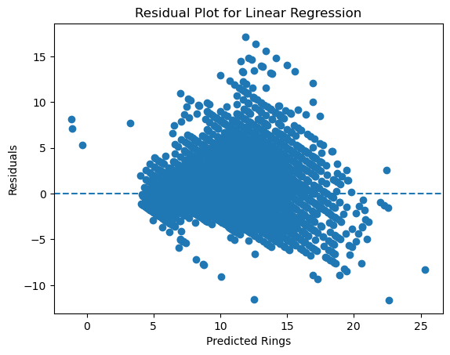

```python
residuals = y_valid - lr_pred

plt.scatter(lr_pred, residuals)
plt.axhline(y=0, linestyle="--")
plt.xlabel("Predicted Rings")
plt.ylabel("Residuals")
plt.title("Residual Plot for Linear Regression")
plt.show()
```

## A residual plot helps check the linearity assumption.

If residuals are randomly scattered around zero, the linear model is more appropriate. Patterns may indicate nonlinearity or unequal variance.

# Create a Q-Q Plot of Residuals

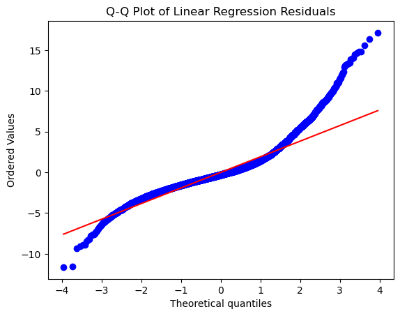

```python
import scipy.stats as stats

stats.probplot(residuals, dist="norm", plot=plt)
plt.title("Q-Q Plot of Linear Regression Residuals")
plt.show()
```

## The Q-Q plot checks whether residuals are approximately normally distributed.

If the points follow the diagonal line closely, the normality assumption is reasonable.

# Create a Correlation Matrix

```python
numeric_data = abalone.select_dtypes(include=np.number)

corr_matrix = numeric_data.corr()

corr_matrix
```

|  | id | Length | Diameter | Height | Whole weight | Whole weight.1 | Whole weight.2 | Shell weight | Rings |
| --- | --- | --- | --- | --- | --- | --- | --- | --- | --- |
| id | 1.000000 | 0.004724 | 0.004290 | 0.005916 | 0.005228 | 0.004203 | 0.004878 | 0.005887 | 0.000938 |
| Length | 0.004724 | 1.000000 | 0.989732 | 0.916094 | 0.931449 | 0.909609 | 0.913134 | 0.911073 | 0.623786 |
| Diameter | 0.004290 | 0.989732 | 1.000000 | 0.919618 | 0.933848 | 0.908466 | 0.914668 | 0.917871 | 0.636832 |
| Height | 0.005916 | 0.916094 | 0.919618 | 1.000000 | 0.902344 | 0.861769 | 0.886132 | 0.904019 | 0.665772 |
| Whole weight | 0.005228 | 0.931449 | 0.933848 | 0.902344 | 1.000000 | 0.971249 | 0.974319 | 0.964201 | 0.617274 |
| Whole weight.1 | 0.004203 | 0.909609 | 0.908466 | 0.861769 | 0.971249 | 1.000000 | 0.949227 | 0.911800 | 0.515067 |
| Whole weight.2 | 0.004878 | 0.913134 | 0.914668 | 0.886132 | 0.974319 | 0.949227 | 1.000000 | 0.937069 | 0.588954 |
| Shell weight | 0.005887 | 0.911073 | 0.917871 | 0.904019 | 0.964201 | 0.911800 | 0.937069 | 1.000000 | 0.694766 |
| Rings | 0.000938 | 0.623786 | 0.636832 | 0.665772 | 0.617274 | 0.515067 | 0.588954 | 0.694766 | 1.000000 |

## This creates a correlation matrix for numeric variables.

It helps identify relationships among predictors and between predictors and the target variable.

# Visualize the Correlation Matrix

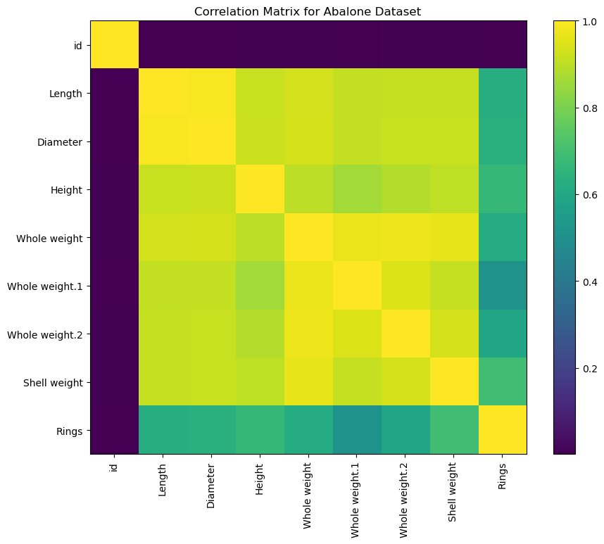

```python
plt.figure(figsize=(10, 8))
plt.imshow(corr_matrix, aspect="auto")
plt.colorbar()
plt.xticks(range(len(corr_matrix.columns)), corr_matrix.columns, rotation=90)
plt.yticks(range(len(corr_matrix.columns)), corr_matrix.columns)
plt.title("Correlation Matrix for Abalone Dataset")
plt.show()
```

## This heatmap visually displays correlations.

Strong correlations between predictors may suggest possible multicollinearity.

# Load the Kaggle Test Dataset

```python
test = pd.read_csv("test.csv/test.csv")
test.head()
```

|  | id | Sex | Length | Diameter | Height | Whole weight | Whole weight.1 | Whole weight.2 | Shell weight |
| --- | --- | --- | --- | --- | --- | --- | --- | --- | --- |
| 0 | 90615 | M | 0.645 | 0.475 | 0.155 | 1.2380 | 0.6185 | 0.3125 | 0.3005 |
| 1 | 90616 | M | 0.580 | 0.460 | 0.160 | 0.9830 | 0.4785 | 0.2195 | 0.2750 |
| 2 | 90617 | M | 0.560 | 0.420 | 0.140 | 0.8395 | 0.3525 | 0.1845 | 0.2405 |
| 3 | 90618 | M | 0.570 | 0.490 | 0.145 | 0.8740 | 0.3525 | 0.1865 | 0.2350 |
| 4 | 90619 | I | 0.415 | 0.325 | 0.110 | 0.3580 | 0.1575 | 0.0670 | 0.1050 |

## This loads the Kaggle test dataset.

The test dataset does not contain the target variable, so it is used only for final prediction and submission.

# Prepare the Test Dataset

```python
test_ids = test["id"]

X_test = test.drop(columns=["id"], errors="ignore")

X_test = pd.get_dummies(X_test, drop_first=True)

X_test = X_test.reindex(columns=X.columns, fill_value=0)
```

## This prepares the test dataset so it has the same columns as the training dataset.

This step is important because Kaggle requires predictions for each test observation ID.

# Generate Final Predictions

```python
test_predictions = rf.predict(X_test)
```

## This uses the Random Forest model to predict Rings for the Kaggle test dataset.

Random Forest is used here because it often performs better on nonlinear data.

# Create Kaggle Submission File

```python
submission = pd.DataFrame({
    "id": test_ids,
    "Rings": test_predictions
})

submission.head()
```

|  | id | Rings |
| --- | --- | --- |
| 0 | 90615 | 9.933333 |
| 1 | 90616 | 9.856667 |
| 2 | 90617 | 10.183333 |
| 3 | 90618 | 11.256667 |
| 4 | 90619 | 8.413333 |

## This creates the submission file in the required Kaggle format.

It must contain the ID column and the predicted Rings column.

# Save Submission File

```python
submission.to_csv("submission.csv", index=False)
```

## This saves the predictions as a CSV file named submission.csv.

You upload this file to Kaggle for scoring.